# Vehicle Detection Project

The goals / steps of this project are the following:

- Perform a Histogram of Oriented Gradients (HOG) feature extraction on a labeled training set of images and train a classifier Linear SVM classifier
- Optionally, you can also apply a color transform and append binned color features, as well as histograms of color, to your HOG feature vector.
- Note: for those first two steps don't forget to normalize your features and randomize a selection for training and testing.
- Implement a sliding-window technique and use your trained classifier to search for vehicles in images.
- Run your pipeline on a video stream (start with the test_video.mp4 and later implement on full project_video.mp4) and create a heat map of recurring detections frame by frame to reject outliers and follow detected vehicles.

### Imports

```python
from skimage.feature import hog
from skimage import data, exposure
import matplotlib.image as mpimg
from mpl_toolkits.axes_grid1 import ImageGrid
import matplotlib.pyplot as plt
%matplotlib inline
import cv2
import glob
import time
import os
import numpy as np
from sklearn.svm import LinearSVC
from sklearn.preprocessing import StandardScaler
from sklearn.cross_validation import train_test_split
from scipy.ndimage.measurements import label
```

## Important functions

#### Color conversion

This function is used to convert between color spaces

```python
# Define a function to convert between color spaces
def convert_color(img, conv='RGB2YCrCb'):
    if conv == 'RGB2YCrCb':
        return cv2.cvtColor(img, cv2.COLOR_RGB2YCrCb)
    if conv == 'BGR2YCrCb':
        return cv2.cvtColor(img, cv2.COLOR_BGR2YCrCb)
    if conv == 'RGB2YUV':
        return cv2.cvtColor(img, cv2.COLOR_RGB2YUV)
    if conv == 'RGB2LUV':
        return cv2.cvtColor(img, cv2.COLOR_RGB2LUV)
    if conv == 'RGB2HLS':
        return cv2.cvtColor(img, cv2.COLOR_RGB2HLS)
    if conv == 'RGB2HSV':
        return cv2.cvtColor(img, cv2.COLOR_RGB2HSV)
```

### Spatial features

The following function extracts features from spatial binning in image space

```python
# Define a function to get feature vector from spatial binning in image space
def bin_spatial(img, size=(32, 32)):
    # Resize and flatten
    color1 = cv2.resize(img[:,:,0], size).ravel()
    color2 = cv2.resize(img[:,:,1], size).ravel()
    color3 = cv2.resize(img[:,:,2], size).ravel()
    return np.hstack((color1, color2, color3))
```

### Color histogram features

This function produces a histogram of pixel intensities for each channel. The image may be of any color space

```python
# Define a function to get the histogram of intensities for each channel
def color_hist(img, nbins=32):
    # Compute the histogram of the color channels separately
    channel1_hist = np.histogram(img[:,:,0], bins=nbins)
    channel2_hist = np.histogram(img[:,:,1], bins=nbins)
    channel3_hist = np.histogram(img[:,:,2], bins=nbins)
    # Concatenate the histograms into a single feature vector
    hist_features = np.concatenate((channel1_hist[0], channel2_hist[0],
                                    channel3_hist[0]))
    # Return the indivisual histograms, bin_centers and feature vector ??
    return hist_features
```

### HOG features

This function extracts the HOG features of the given image. If `vis` is `True`, it also returns an image visualizing the HOG features

```python
# Define a function to return HOG features and visualization
def get_hog_features(img, orient, pix_per_cell, cell_per_block,
                     vis=False, feature_vec=True):
    # Call with two outputs if vis==True
    if vis == True:
        features, hog_img = hog(img, orientations=orient,
                                pixels_per_cell=(pix_per_cell, pix_per_cell),
                                cells_per_block=(cell_per_block, cell_per_block),
                                transform_sqrt=False,
                                visualise=vis, feature_vector=feature_vec)
        return features, hog_img
    # Otherwise call with one output
    else:
        features = hog(img, orientations=orient,
                       pixels_per_cell=(pix_per_cell, pix_per_cell),
                       cells_per_block=(cell_per_block, cell_per_block),
                       transform_sqrt=False,
                       visualise=vis, feature_vector=feature_vec)
        return features
```

#### Extract specified features

This function ties together the above functions

```python
# Define a function to extract features from a list of image locations
# This function could also be used to call bin_spatial() and color_hist() (as in the lessons) to extract
# flattened spatial color features and color histogram features and combine them all (making use of StandardScaler)
# to be used together for classification
def extract_features(imgs, cspace='RGB', orient=9,
                        pix_per_cell=8, cell_per_block=2, hog_channel=0):
    # Create a list to append feature vectors to
    features = []
    # Iterate through the list of images
    for file in imgs:
        # Read in each one by one
        image = mpimg.imread(file)
        # apply color conversion if other than 'RGB'
        if cspace != 'RGB':
            if cspace == 'HSV':
                feature_image = cv2.cvtColor(image, cv2.COLOR_RGB2HSV)
            elif cspace == 'LUV':
                feature_image = cv2.cvtColor(image, cv2.COLOR_RGB2LUV)
            elif cspace == 'HLS':
                feature_image = cv2.cvtColor(image, cv2.COLOR_RGB2HLS)
            elif cspace == 'YUV':
                feature_image = cv2.cvtColor(image, cv2.COLOR_RGB2YUV)
            elif cspace == 'YCrCb':
                feature_image = cv2.cvtColor(image, cv2.COLOR_RGB2YCrCb)
        else: feature_image = np.copy(image)

        # Call get_hog_features() with vis=False, feature_vec=True
        if hog_channel == 'ALL':
            hog_features = []
            for channel in range(feature_image.shape[2]):
                hog_features.append(get_hog_features(feature_image[:,:,channel],
                                    orient, pix_per_cell, cell_per_block,
                                    vis=False, feature_vec=True))
            hog_features = np.ravel(hog_features)
        else:
            hog_features = get_hog_features(feature_image[:,:,hog_channel], orient,
                        pix_per_cell, cell_per_block, vis=False, feature_vec=True)
        # Append the new feature vector to the features list
        features.append(hog_features)
    # Return list of feature vectors
    return features
```

## Car finding functions

#### Generate heatmaps

This function generates heatmap given a list of bounding boxes

```python
# Define a function to generate a heat map given a list of bounding boxes
def add_heat(heatmap, bbox_list):
    # Iterate through list of bboxes:
    for box in bbox_list:
        # Add += 1 for all pixels inside each bbox
        # Assuming each "box" takes the form ((x1, y1), (x2, y2))
        heatmap[box[0][1]:box[1][1], box[0][0]:box[1][0]] += 1

    # Return the update heatmap
    return heatmap
```

#### Apply threshold to a heatmap

This function zeros out any values in the heatmap that are below the threshold

```python
# Define a function to apply threshold to the heatmap
def apply_threshold(heatmap, threshold):
    # Zero out pixels below the threshold
    heatmap[heatmap <= threshold] = 0
    # Return thresholded map
    return heatmap
```

#### Draw bounding boxes for labels

Given a set of labels for the blobs present in the thresholded heatmap, this function generates a convex bounding box encapsulating the blob

```python
# Define a function to draw bounding boxes given the labels
def draw_labeled_bboxes(img, labels):
    # Iterate through all detected cars
    for car_number in range(1, labels[1]+1):
        # Find pixels with each car_number label value
        nonzero = (labels[0] == car_number).nonzero()
        # Identify x and y values of those pixels
        nonzeroy = np.array(nonzero[0])
        nonzerox = np.array(nonzero[1])
        # Define a bounding box based on min/max x and y
        bbox = ((np.min(nonzerox), np.min(nonzeroy)), (np.max(nonzerox),  np.max(nonzeroy)))
        # Draw the box on the image
        cv2.rectangle(img, bbox[0], bbox[1], (0,0,255), 6)
    # Return the image
    return img
```

### Function to find cars

```python
# Define a single function that can extract features using hog sub-sampling and make predictions
def find_cars(img, svc, X_scaler, params, scale=None):
    """
    ystart, ystop: Height of the ROI in which to find cars
    scale: ___________________
    svc: Trained classifier model
    X_scaler: Feature scaler for normalizing the features
    orient: Number of orientations for HOG
    pix_per_cell: Pixels per HOG cell
    cell_per_block: Cells per HOG block
    spatial_size: _____________
    hist_bins: Number of bins in the color histogram
    """
    if scale is None:
        scale = params.scale
    spatial_size = params.spatial_size
    hist_bins = params.hist_bins

    # array of rectangles where cars were detected
    bboxlist = []

    # Image to draw on
    draw_img = np.copy(img)
    img = img.astype(np.float32)/255

    img_tosearch = img[params.ystart:params.ystop,:,:]

    # apply color conversion if other than 'RGB'
    if params.colorspace != 'RGB':
        if params.colorspace == 'HSV':
            ctrans_tosearch = cv2.cvtColor(img_tosearch, cv2.COLOR_RGB2HSV)
        elif params.colorspace == 'LUV':
            ctrans_tosearch = cv2.cvtColor(img_tosearch, cv2.COLOR_RGB2LUV)
        elif params.colorspace == 'HLS':
            ctrans_tosearch = cv2.cvtColor(img_tosearch, cv2.COLOR_RGB2HLS)
        elif params.colorspace == 'YUV':
            ctrans_tosearch = cv2.cvtColor(img_tosearch, cv2.COLOR_RGB2YUV)
        elif params.colorspace == 'YCrCb':
            ctrans_tosearch = cv2.cvtColor(img_tosearch, cv2.COLOR_RGB2YCrCb)
    else: ctrans_tosearch = np.copy(image)

    # rescale image if other than 1.0 scale
    if scale != 1:
        imshape = ctrans_tosearch.shape
        ctrans_tosearch = cv2.resize(ctrans_tosearch, (np.int(imshape[1]/scale), np.int(imshape[0]/scale)))

    # select colorspace channel for HOG
    if params.hog_channel == 'ALL':
        ch1 = ctrans_tosearch[:,:,0]
        ch2 = ctrans_tosearch[:,:,1]
        ch3 = ctrans_tosearch[:,:,2]
    else:
        ch1 = ctrans_tosearch[:,:,params.hog_channel]

    #ctrans_channels = [ch1, ch2, ch3]

    # Define blocks and steps as above
    nxblocks = (ch1.shape[1] // params.pix_per_cell)+1  #-1
    nyblocks = (ch1.shape[0] // params.pix_per_cell)+1  #-1
    nfeat_per_block = params.orient * params.cell_per_block**2
    # 64 was the orginal sampling rate, with 8 cells and 8 pix per cell
    window = 64
    nblocks_per_window = (window // params.pix_per_cell)-1
    cells_per_step = 2  # Instead of overlap, define how many cells to step
    nxsteps = (nxblocks - nblocks_per_window) // cells_per_step
    nysteps = (nyblocks - nblocks_per_window) // cells_per_step

    # Compute individual channel HOG features for the entire image
    if params.hog_channel == 'ALL':
        hog1 = get_hog_features(ch1, params.orient, params.pix_per_cell, params.cell_per_block, feature_vec=False)
        hog2 = get_hog_features(ch2, params.orient, params.pix_per_cell, params.cell_per_block, feature_vec=False)
        hog3 = get_hog_features(ch3, params.orient, params.pix_per_cell, params.cell_per_block, feature_vec=False)
    else:
        hog = get_hog_features(ch1, params.orient, params.pix_per_cell, params.cell_per_block, feature_vec=False)

    for xb in range(nxsteps):
        for yb in range(nysteps):
            ypos = yb*cells_per_step
            xpos = xb*cells_per_step
            # Extract HOG for this patch
            if params.hog_channel == 'ALL':
                hog_feat1 = hog1[ypos:ypos+nblocks_per_window, xpos:xpos+nblocks_per_window].ravel()
                hog_feat2 = hog2[ypos:ypos+nblocks_per_window, xpos:xpos+nblocks_per_window].ravel()
                hog_feat3 = hog3[ypos:ypos+nblocks_per_window, xpos:xpos+nblocks_per_window].ravel()
                hog_features = np.hstack((hog_feat1, hog_feat2, hog_feat3)).reshape(1, -1)
            else:
                hog_feat = hog[ypos:ypos+nblocks_per_window, xpos:xpos+nblocks_per_window].ravel()
                hog_features = hog_feat

            xleft = xpos*params.pix_per_cell
            ytop = ypos*params.pix_per_cell

            test_prediction = svc.predict(hog_features)

            if test_prediction == 1:
                xbox_left = np.int(xleft*scale)
                ytop_draw = np.int(ytop*scale)
                win_draw = np.int(window*scale)
                bbox = ((xbox_left, ytop_draw+params.ystart),(xbox_left+win_draw,ytop_draw+win_draw+params.ystart))
                cv2.rectangle(draw_img, bbox[0], bbox[1], (0,0,255), 6)
                bboxlist.append(bbox)

    return draw_img, bboxlist
```

## Dataset

The Udacity labeled dataset is used in this project to train the classifier.

It contains two classes of images: vehicle and non-vehicle. In the following, the images are loaded and a few samples of it are visualised

```python
def getImgPaths(basepath, dirlist):
    img_list = []
    for dirname in dirlist:
        path = os.path.join(basepath, dirname, '*.png')
        imgs = glob.glob(path)
        img_list.extend(imgs)
    return img_list
```

```python
datadir = 'data'
vehicle_dirs = ['GTI_Far', 'GTI_Left', 'GTI_MiddleClose', 'GTI_Right', 'KITTI_extracted']
nonvehicle_dirs = ['Extras', 'GTI']

cars = getImgPaths(os.path.join(datadir, 'vehicles'), vehicle_dirs)
notcars = getImgPaths(os.path.join(datadir, 'non-vehicles'), nonvehicle_dirs)

print('There are', len(cars), 'vehicle images and', len(notcars), 'non-vehicle images')
```

```
There are 8792 vehicle images and 8968 non-vehicle images
```

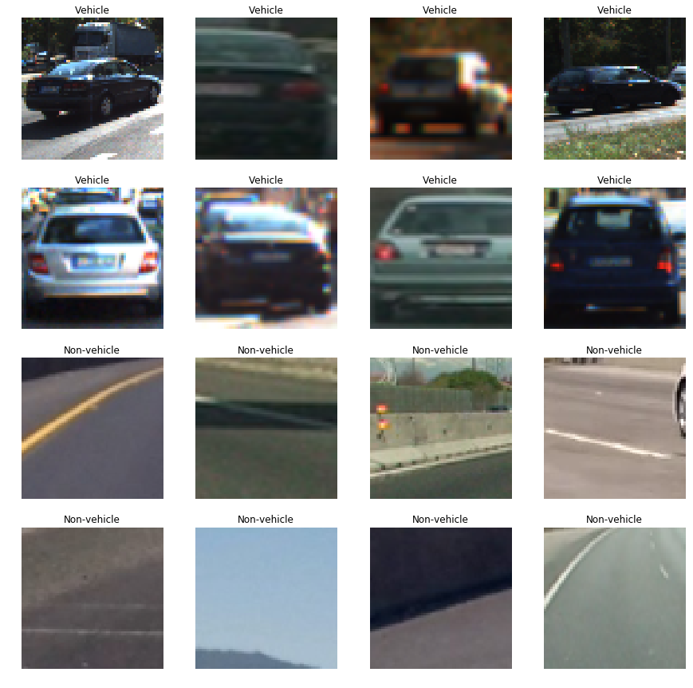

```python
fig = plt.figure(figsize=(15,15))
for i in range(8):
    ax = fig.add_subplot(4, 4, i+1)
    img = cv2.imread(cars[np.random.randint(0, len(cars))])
    img = cv2.cvtColor(img, cv2.COLOR_BGR2RGB)
    ax.set_title('Vehicle')
    plt.axis('off')
    plt.imshow(img)
for i in range(8, 16):
    ax = fig.add_subplot(4, 4, i+1)
    img = cv2.imread(notcars[np.random.randint(0, len(notcars))])
    img = cv2.cvtColor(img, cv2.COLOR_BGR2RGB)
    ax.set_title('Non-vehicle')
    plt.axis('off')
    plt.imshow(img)
```

## Feature extraction

### Parameters

The following class encapsulates various parameters needed for feature extraction as well as for vehicle detection

```python
class Parameters:
    def __init__(self):
        self.colorspace = 'YUV'  # RGB, HSV, LUV, HLS, YUV, YCrCb
        self.orient = 11
        self.pix_per_cell = 16
        self.cell_per_block = 2
        self.hog_channel = 'ALL'  # 0, 1, 2, 'ALL'

        self.ystart = 350
        self.ystop = 656
        self.scale = 2.0
        self.spatial_size = (32,32)
        self.hist_bins = 32
```

This is the parameter which will hold the paramters used for this project.

```python
params = Parameters()

params.colorspace = 'YUV'
params.orient = 11
params.pix_per_cell = 16
params.cell_per_block = 2
# I'm not using these two features
params.spatial_size = None
params.hist_bins = None

# Flag to flip the images along the vertical axis
flip = False

# This is a list of scales and their corresponding ROIs at which to search
# Borrowed from here: https://github.com/jeremy-shannon/CarND-Vehicle-Detection
scales_roi = [(1.0, 400, 464), (1.0, 416, 480),
              (1.5, 400, 496), (1.5, 432, 528),
              (2.0, 400, 528), (2.0, 432, 560),
              (3.5, 400, 596), (3.5, 464, 660)]
```

#### Optionally work on smaller dataset

```python
#sample_size = 1500
#cars = cars[0:sample_size]
#notcars = notcars[0:sample_size]
```

### Extract and visualise

The following code cells show how the features are extracted and displays some visualizations of HOG features

```
/home/md/Frameworks/anaconda3/envs/carnd-term1-gpu/lib/python3.5/site-packages/skimage/feature/_hog.py:119: skimage_deprecation: Default value of `block_norm`==`L1` is deprecated and will be changed to `L2-Hys` in v0.15
  'be changed to `L2-Hys` in v0.15', skimage_deprecation)
```

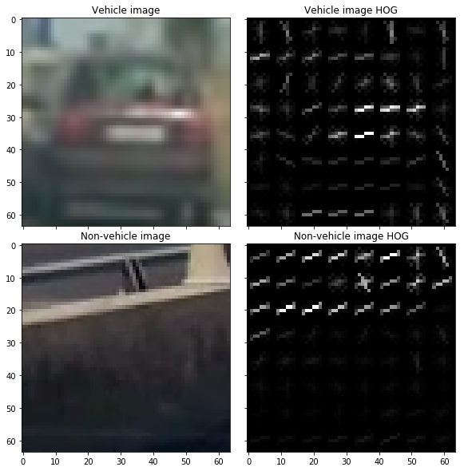

```python
car = cv2.cvtColor(cv2.imread(cars[10]), cv2.COLOR_BGR2RGB)
notcar = cv2.cvtColor(cv2.imread(notcars[10]), cv2.COLOR_BGR2RGB)

_, car_vis = get_hog_features(car[:,:,0], 9, 8, 8, vis=True, feature_vec=True)
_, notcar_vis = get_hog_features(notcar[:,:,0], 9, 8, 8, vis=True, feature_vec=True)

fig = plt.figure(1, (10, 10))
grid = ImageGrid(fig, 111,  # similar to subplot(111)
                 nrows_ncols=(2, 2),  # creates 2x2 grid of axes
                 axes_pad=0.3,  # pad between axes in inch.
                 )
grid[0].imshow(car)
grid[0].set_title('Vehicle image')
grid[1].imshow(car_vis, cmap='gray')
grid[1].set_title('Vehicle image HOG')
grid[2].imshow(notcar)
grid[2].set_title('Non-vehicle image')
grid[3].imshow(notcar_vis, cmap='gray')
grid[3].set_title('Non-vehicle image HOG')
```

## Classifier

### Extract features for the entire dataset

```python
t = time.time()
car_features = extract_features(cars,
                               cspace=params.colorspace,
                               orient=params.orient,
                               pix_per_cell=params.pix_per_cell,
                               cell_per_block=params.cell_per_block,
                               hog_channel=params.hog_channel)

t2 = time.time()
print(round(t2-t, 2), 'Seconds to extract', len(car_features), 'HOG features for ', len(cars), 'images')
```

```
/home/md/Frameworks/anaconda3/envs/carnd-term1-gpu/lib/python3.5/site-packages/skimage/feature/_hog.py:119: skimage_deprecation: Default value of `block_norm`==`L1` is deprecated and will be changed to `L2-Hys` in v0.15
  'be changed to `L2-Hys` in v0.15', skimage_deprecation)
```

```
526.47 Seconds to extract 8792 HOG features for  8792 images
```

```python
t = time.time()
notcar_features = extract_features(notcars,
                               cspace=params.colorspace,
                               orient=params.orient,
                               pix_per_cell=params.pix_per_cell,
                               cell_per_block=params.cell_per_block,
                               hog_channel=params.hog_channel)

t2 = time.time()
print(round(t2-t, 2), 'Seconds to extract', len(notcar_features),' HOG features for ', len(notcars), 'images')
```

```
/home/md/Frameworks/anaconda3/envs/carnd-term1-gpu/lib/python3.5/site-packages/skimage/feature/_hog.py:119: skimage_deprecation: Default value of `block_norm`==`L1` is deprecated and will be changed to `L2-Hys` in v0.15
  'be changed to `L2-Hys` in v0.15', skimage_deprecation)
```

```
493.34 Seconds to extract 8968  HOG features for  8968 images
```

```python
# This will create a single vector of features and labels
X = np.vstack((car_features, notcar_features)).astype(np.float64)
y = np.hstack((np.ones(len(car_features)), np.zeros(len(notcar_features))))
```

#### Split the data into train and test sets

```python
rand_state = np.random.randint(0, 100)
X_train, X_test, y_train, y_test = train_test_split(X, y,
                                                  test_size=0.2,
                                                  random_state=rand_state)
```

#### Normalize the data

This is not needed if we are using only the HOG features

```python
#X_scaler = StandardScaler().fit(X_train)
# Apply the scaler to X
#X_train = X_scaler.transform(X_train)
#X_test = X_scaler.transform(X_test)
```

### Train the classifier

Here I train the classifier on the training set. I'm useing a Linear SVM from scikit-learn with default parameters

```python
svc = LinearSVC()
t = time.time()
svc.fit(X_train, y_train)
t2 = time.time()
print(round(t2-t, 2), 'Seconds to train SVC with ', len(X_train), 'data points')
```

```
22.23 Seconds to train SVC with  14208 data points
```

#### Test on test set

```python
print('Accuracy on test set = ',
     round(svc.score(X_test, y_test), 4))
```

```
Accuracy on test set =  0.98
```

## Test on images

```python
# Here is your draw_boxes function from the previous exercise
def draw_boxes(img, bboxes, color=(0, 0, 255), thick=6):
    # Make a copy of the image
    imcopy = np.copy(img)
    random_color = False
    # Iterate through the bounding boxes
    for bbox in bboxes:
        if color == 'random' or random_color:
            color = (np.random.randint(0,255), np.random.randint(0,255), np.random.randint(0,255))
            random_color = True
        # Draw a rectangle given bbox coordinates
        cv2.rectangle(imcopy, bbox[0], bbox[1], color, thick)
    # Return the image copy with boxes drawn
    return imcopy
```

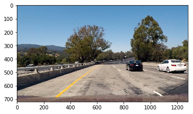

```python
img = cv2.imread('./test_images/test1.jpg')
img = cv2.cvtColor(img, cv2.COLOR_BGR2RGB)
plt.imshow(img)
```

```python
bboxlist = []
params.ystart = 400
X_scaler = None
out_img, bboxlist = find_cars(img, svc, X_scaler, params, scale=1.5)
print(len(bboxlist))
```

```
/home/md/Frameworks/anaconda3/envs/carnd-term1-gpu/lib/python3.5/site-packages/skimage/feature/_hog.py:119: skimage_deprecation: Default value of `block_norm`==`L1` is deprecated and will be changed to `L2-Hys` in v0.15
  'be changed to `L2-Hys` in v0.15', skimage_deprecation)
```

```
4
```

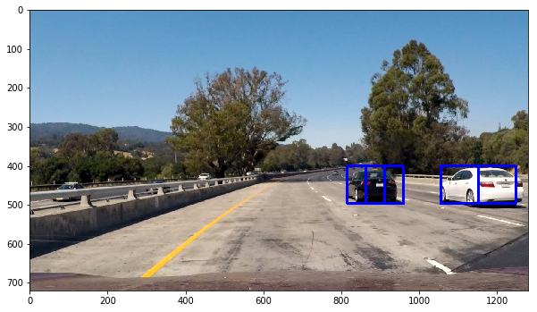

```python
plt.figure(figsize=(10,10))
plt.imshow(out_img)
```

### Multiple scales

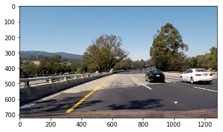

```python
img = cv2.imread('./test_images/test4.jpg')
img = cv2.cvtColor(img, cv2.COLOR_BGR2RGB)
plt.imshow(img)
```

```python
bbox_list = []
for item in scales_roi:
    scale, params.ystart, params.ystop = item
    _, bboxlist = find_cars(img, svc, X_scaler, params, scale)
    bbox_list.extend(bboxlist)
```

```
/home/md/Frameworks/anaconda3/envs/carnd-term1-gpu/lib/python3.5/site-packages/skimage/feature/_hog.py:119: skimage_deprecation: Default value of `block_norm`==`L1` is deprecated and will be changed to `L2-Hys` in v0.15
  'be changed to `L2-Hys` in v0.15', skimage_deprecation)
```

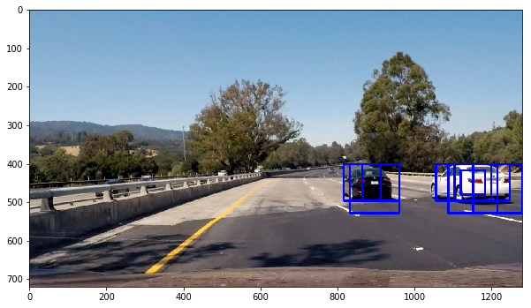

```python
draw_img = draw_boxes(img, bbox_list, color=[0,0,255], thick=3)
plt.figure(figsize=(10,10))
plt.imshow(draw_img)
```

```python
images.append(draw_img)
```

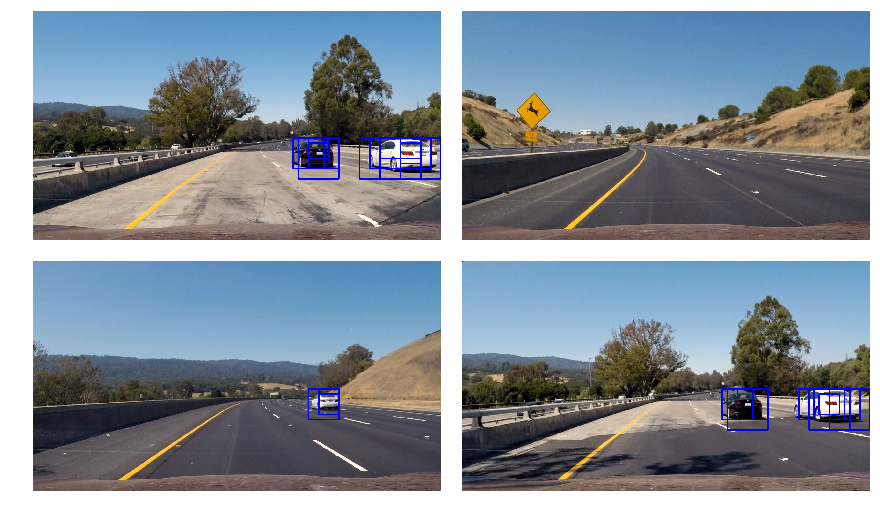

```python
fig = plt.figure(1, (15, 15))
grid = ImageGrid(fig, 111,  # similar to subplot(111)
                 nrows_ncols=(2, 2),  # creates 2x2 grid of axes
                 axes_pad=0.3,  # pad between axes in inch.
                 )
for i in range(0,4):
    grid[i].imshow(images[i])
    grid[i].axis('off')
```

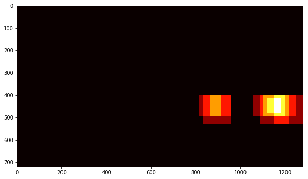

```python
heatmap = np.zeros_like(img[:,:,0], dtype='float')
heatmap = add_heat(heatmap, bbox_list)
plt.figure(figsize=(10,10))
plt.imshow(heatmap, cmap='hot')
```

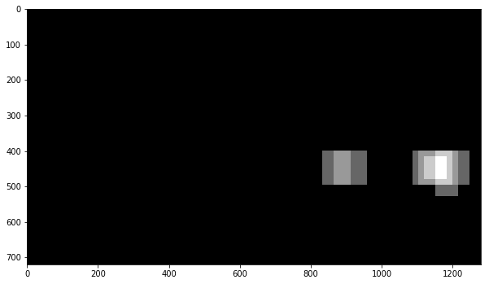

```python
thresh_heatmap = apply_threshold(heatmap, 1)
plt.figure(figsize=(10,10))
plt.imshow(thresh_heatmap, cmap='gray')
```

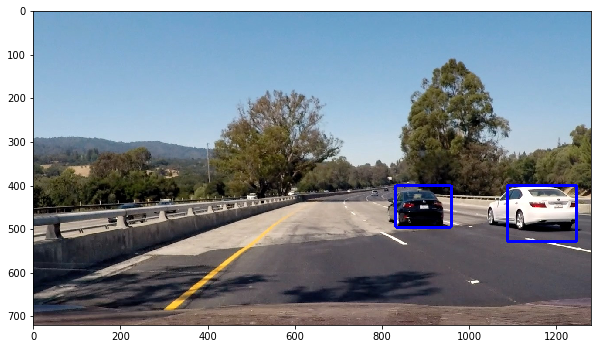

```python
labels = label(thresh_heatmap)
draw_img = draw_labeled_bboxes(np.copy(img), labels)
plt.figure(figsize=(10,10))
plt.imshow(draw_img)
```

## Video pipeline

```python
# Import everything needed to edit/save/watch video clips
from moviepy.editor import VideoFileClip
from IPython.display import HTML
```

```python
class VehicleDetector:
    def __init__(self, svc, X_scaler, params, frames_buffer=15, scales=None, thresh=5):
        self.frame = 0
        self.params = params

        self.svc = svc
        self.X_scaler = X_scaler

        # Deprecated
        if scales is None:
            self.scales = [1.0, 1.25, 1.5, 2.0, 3.0]
        else:
            self.scales = scales

        self.thresh = thresh

        self.history = {}

        self.prev_bboxlist = []

    def writeFrame(self, img, directory):
        image = cv2.cvtColor(img, cv2.COLOR_RGB2BGR)
        cv2.imwrite("{}/frame{:04d}_C{}.png".format(directory, self.frame, len(img.shape)), image)

    def addBBox(self, rects):
        self.prev_rects.append(rects)
        if len(self.prev_rects) > self.frames_buffer:
            self.prev_rects = self.prev_rects[len(self.prev_rects)-self.frames_buffer:]

    def processFrame(self, img):
        if self.frame % 3 == 0:
            pass
        bbox_list = []
        for item in scales_roi:
            scale, self.params.ystart, self.params.ystop = item
            _, bboxlist = find_cars(img, self.svc, self.X_scaler, self.params, scale)
            bbox_list.extend(bboxlist)

        # add detections to the history
        if len(bbox_list) > 0:
            self.add_rects(bbox_list)

        heatmap = np.zeros_like(img[:,:,0])
        for bboxes in self.prev_bboxlist:
            heatmap = addBBox(heatmap, bboxes)
        heatmap = apply_threshold(heatmap, 1 + len(self.bboxes)//2)

        labels = label(heatmap)

        draw_img = draw_labeled_bboxes(np.copy(img), labels)
        draw_img = cv2.putText(draw_img, "Frame: {0}".format(self.frame), (10, 150), cv2.FONT_HERSHEY_SIMPLEX, 1.25, [255,255,255], 2)

        return draw_img
```

```python
output = 'projectvideo_output.mp4'
video_params = params   # Parameters()
vd = VehicleDetector(svc, None, video_params, frames_buffer=10, scales=[1.5, 2.0, 2.5, 3.0],
                     thresh=1)
## To speed up the testing process you may want to try your pipeline on a shorter subclip of the video
## To do so add .subclip(start_second,end_second) to the end of the line below
## Where start_second and end_second are integer values representing the start and end of the subclip
## You may also uncomment the following line for a subclip of the first 5 seconds
##clip1 = VideoFileClip("test_videos/solidWhiteRight.mp4").subclip(0,5)
clip1 = VideoFileClip("project_video.mp4") #.subclip(14,31)
out_clip = clip1.fl_image(vd.processFrame) #NOTE: this function expects color images!!
%time out_clip.write_videofile(output, audio=False)
```

```
[MoviePy] >>>> Building video projectvideo_output.mp4
[MoviePy] Writing video projectvideo_output.mp4
```

```
[MoviePy] Done.
[MoviePy] >>>> Video ready: projectvideo_output.mp4

CPU times: user 8min 57s, sys: 2.47 s, total: 9min
Wall time: 44min 51s
```

```python
HTML("""
<video width="960" height="540" controls>
  <source src="{0}">
</video>
""".format(output))
```

[video not shown]